# Advanced DataVisualization with ggplot

```r
require(ggplot2)
```

## Advanced DataVisualization with ggplot - Statistics

Stats and Genomes

There are two brought categories:

- those called from within the geom
- those that are called indipendently

Statistical layers are often already involved in basic Visualization Function in ggplot2. For example in the histogram geometric layer.

Under the hood this function calls the `stat_bin()` method to create the necessary table.

```r
p <- ggplot(iris, aes(Sepal.Width))
p <- p + geom_histogram()
# Investigating the histogram object
attributes(p)
```

```
$names
[1] "data"        "layers"      "scales"      "mapping"     "theme"       "coordinates" "facet"       "plot_env"
[9] "labels"

$class
[1] "gg"     "ggplot"
```

```r
# Looking at the layers produces (We see there is a stat_bin layer involved)
p$layers
```

```
[[1]]
geom_bar: na.rm = FALSE
stat_bin: binwidth = NULL, bins = NULL, na.rm = FALSE, pad = FALSE
position_stack
```

```r
# Lets take a closer look. This can not be accessed directly
p$layers[[1]]
```

```
geom_bar: na.rm = FALSE
stat_bin: binwidth = NULL, bins = NULL, na.rm = FALSE, pad = FALSE
position_stack
```

Using the `ggplot_build()` function can help us get access to all intermediate results

```r
ggplot_build(p)$data
```

| y | count | x | xmin | xmax | density | ncount | ndensity | PANEL | group | ymin | ymax | colour | fill | size | linetype | alpha |
| --- | --- | --- | --- | --- | --- | --- | --- | --- | --- | --- | --- | --- | --- | --- | --- | --- |
| 1 | 1 | 1.986207 | 1.944828 | 2.027586 | 0.08055556 | 0.03846154 | 0.4774536 | 1 | -1 | 0 | 1 | NA | grey35 | 0.5 | 1 | NA |
| 0 | 0 | 2.068966 | 2.027586 | 2.110345 | 0.00000000 | 0.00000000 | 0.0000000 | 1 | -1 | 0 | 0 | NA | grey35 | 0.5 | 1 | NA |
| 0 | 0 | 2.151724 | 2.110345 | 2.193103 | 0.00000000 | 0.00000000 | 0.0000000 | 1 | -1 | 0 | 0 | NA | grey35 | 0.5 | 1 | NA |
| 3 | 3 | 2.234483 | 2.193103 | 2.275862 | 0.24166667 | 0.11538462 | 1.4323607 | 1 | -1 | 0 | 3 | NA | grey35 | 0.5 | 1 | NA |
| 4 | 4 | 2.317241 | 2.275862 | 2.358621 | 0.32222222 | 0.15384615 | 1.9098143 | 1 | -1 | 0 | 4 | NA | grey35 | 0.5 | 1 | NA |
| 3 | 3 | 2.400000 | 2.358621 | 2.441379 | 0.24166667 | 0.11538462 | 1.4323607 | 1 | -1 | 0 | 3 | NA | grey35 | 0.5 | 1 | NA |
| 8 | 8 | 2.482759 | 2.441379 | 2.524138 | 0.64444444 | 0.30769231 | 3.8196286 | 1 | -1 | 0 | 8 | NA | grey35 | 0.5 | 1 | NA |
| 5 | 5 | 2.565517 | 2.524138 | 2.606897 | 0.40277778 | 0.19230769 | 2.3872679 | 1 | -1 | 0 | 5 | NA | grey35 | 0.5 | 1 | NA |
| 0 | 0 | 2.648276 | 2.606897 | 2.689655 | 0.00000000 | 0.00000000 | 0.0000000 | 1 | -1 | 0 | 0 | NA | grey35 | 0.5 | 1 | NA |
| 9 | 9 | 2.731034 | 2.689655 | 2.772414 | 0.72500000 | 0.34615385 | 4.2970822 | 1 | -1 | 0 | 9 | NA | grey35 | 0.5 | 1 | NA |

[output cut: 20 more lines]

```
NA
```

This leads to different possible implementations for the underlying calculation

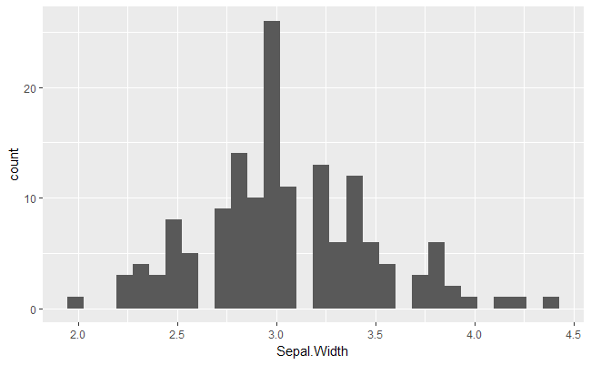

```r
p <- ggplot(iris, aes(Sepal.Width))
# As a histogram function
p + geom_histogram()
```

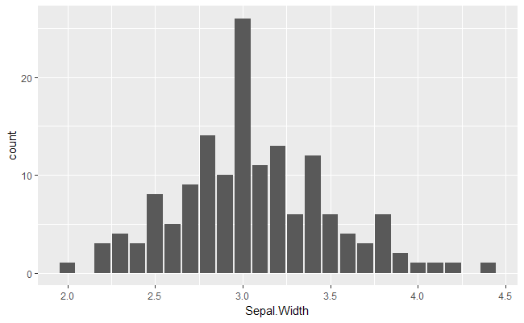

```r
# As a BarPlot
p  + geom_bar()
```

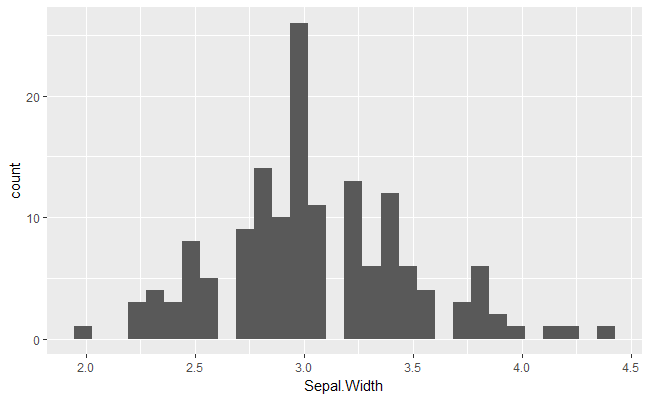

```r
# Directly with the statistical function call
p + stat_bin(bins = 30)
```

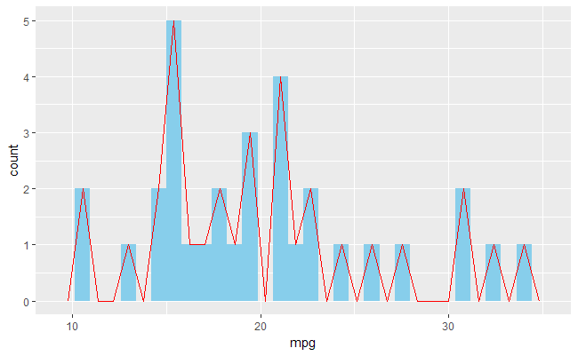

```r
ggplot(mtcars, aes(mpg)) +
  geom_histogram( fill = "skyblue") +
  geom_freqpoly(col = "red")
```

### Calling the `stat_smooth()` Stats layer directly from within ggplot

We are using the `geom_smooth()` to attribute the necessary variables to the calculation.

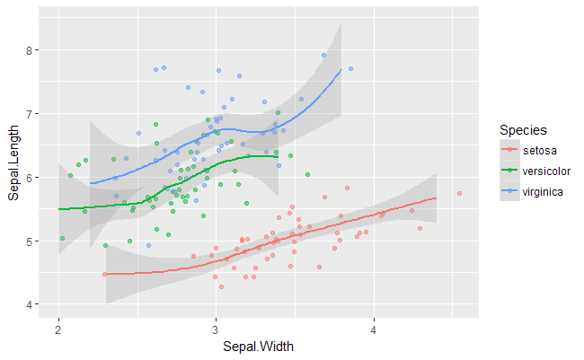

```r
# Fitting individual loess models per Species
ggplot(iris, aes(Sepal.Width, Sepal.Length, col = Species)) +
  geom_point(position = position_jitter(width = 0.2), alpha = 0.5) +
  geom_smooth(method = "loess", se = TRUE, span = 0.9, alpha = 0.25)
```

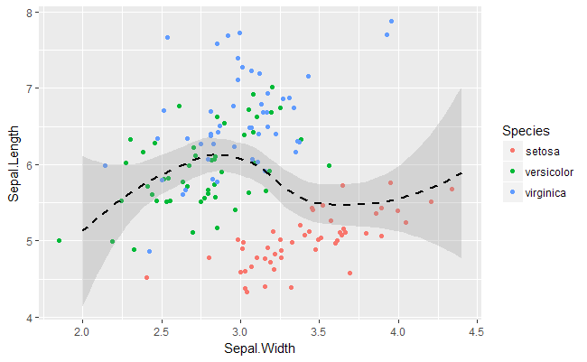

```r
# Plotting the data to fit the "loess" sliding window mean calculation over all groups
ggplot(iris, aes(Sepal.Width, Sepal.Length, col = Species, group = 1)) +
  geom_point(position = position_jitter(width = 0.2)) +
  geom_smooth(method = "loess", se = TRUE, span = 0.8, col = "black", lty = 2, alpha = 0.3)
```

All these fitted models are not predictive in themselfes. They only span the range of given values on the x-Axis.

To predict over the full range of x-values set, we can set the `fullrange = TRUE` argument.

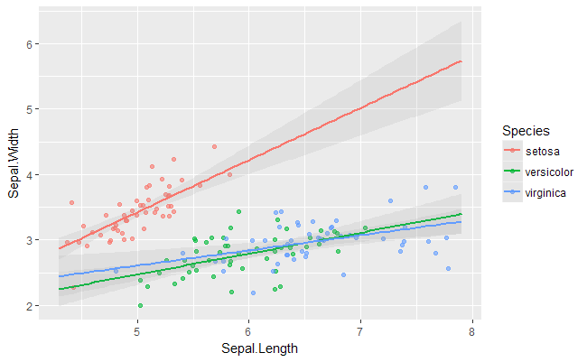

```r
ggplot(iris, aes(Sepal.Length, Sepal.Width, col = Species)) +
  geom_point(alpha = 0.6, position = position_jitter(width = 0.2)) +
  geom_smooth(method = "lm", fullrange = TRUE, alpha = 0.15)
```

These are all other existing stats functions we will encounter later:

stat_ || geom_

stat_bin() || geom_histogram() stat_bin() || geom_bar() stat_bin() || geom_freqpoly() stat_smooth() || geom_smooth() stat_boxplot() || geom_boxplot() stat_bindot() || geom_dotplot() stat_bin2d() || geom_bin2d() stat_binhex() || geom_hex() stat_contour() || geom_contour() stat_quantile() || geom_quantile() stat_sum() || geom_count()

You never have to call these stat_functions directly in ggplot, but understanding their attributes and arguments will enable a more sophisticated control over their behaviour. Enabling better understanding of warning messages and dealing with the respective helpfiles associated with the `stats package`

### Here are some exercises

Plotting both grouped models and a general model

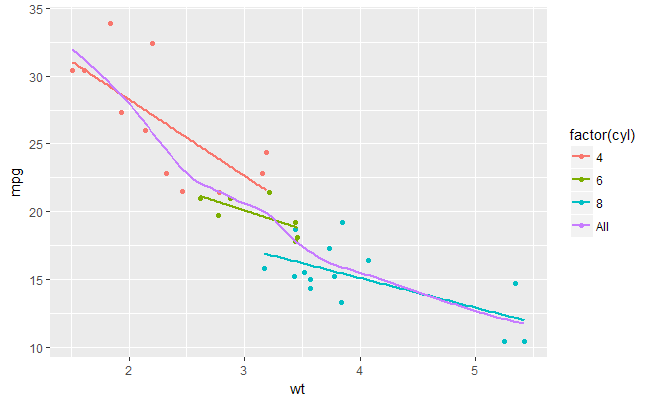

```r
# First we plot the basic dataplot
ggplot(mtcars, aes(wt, mpg, col = factor(cyl))) +

# Then we add a grouped linear model
  geom_point() +
  geom_smooth(method = "lm", se = F, fullrange = F) +

# And then add an ungrouped model
  geom_smooth(method = "loess", se = F, aes(group = 1, col = "All"), span = 0.7)
```

## Using statistics from outside the ggplot function

Summary statistics, confidence interval calculations etc. can easily be included into the plot trough dedicated ggplot functions, transforming the table results into dataframes and changing their values to be joined into the underlying ggplot 2 calculation dataframes.

Most of the functions called here, are from the `Hmisc()` package.

```r
require(Hmisc)
# Calculating a 95% CI
smean.cl.normal(xx)
```

```
Error in smean.cl.normal(xx) : object 'xx' not found
```

These functions can give us information on the distribution of our data, useable when working with statistical tests in R, as those make assumptions about the underlying data.

```r
# Summarise y values at distinct x values
stat_summary()
```

```
geom_pointrange: na.rm = FALSE
stat_summary: fun.data = NULL, fun.y = NULL, fun.ymax = NULL, fun.ymin = NULL, fun.args = list(), na.rm = FALSE
position_identity
```

```r
# Compute y values from a function of x values
stat_function()
```

```
Error in layer(data = data, mapping = mapping, stat = StatFunction, geom = geom,  :
  argument "fun" is missing, with no default
```

## Calculating a normal distribution to check for model accordance in our data

```
Ignoring unknown parameters: arg
```

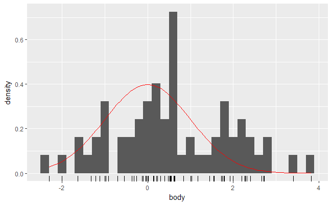

```r
library(MASS)
# We plot the normal density against the log linearly transformed dataset to visually inspect the data
mam.new <- data.frame(body = log10(mammals$body))
ggplot(mam.new, aes(body)) +
  geom_histogram(aes(y = ..density..), binwidth = 0.2) +
  geom_rug() +
  stat_function(fun = dnorm, colour = "red",
                arg = list(mean = mean(mam.new$body),
                           sd = sd(mam.new$body)))
```

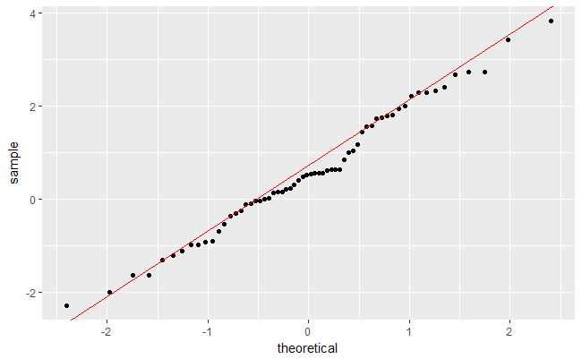

```r
# Or we use the qqplot to graphically represent it
mam.new$slope <- diff(quantile(mam.new$body, c(0.25, 0.75))) /
  diff(qnorm(c(0.25, 0.75)))
mam.new$int <- quantile(mam.new$body, 0.25) - mam.new$slope * qnorm(0.25)
ggplot(mam.new, aes(sample = body)) +
  stat_qq()  +
  geom_abline(aes(slope = slope, intercept = int), col = "red")
```

```r
# inspecting the dataset
str(mtcars)
```

```
'data.frame':   32 obs. of  13 variables:
 $ mpg   : num  21 21 22.8 21.4 18.7 18.1 14.3 24.4 22.8 19.2 ...
 $ cyl   : Factor w/ 3 levels "4","6","8": 2 2 1 2 3 2 3 1 1 2 ...
 $ disp  : num  160 160 108 258 360 ...
 $ hp    : num  110 110 93 110 175 105 245 62 95 123 ...
 $ drat  : num  3.9 3.9 3.85 3.08 3.15 2.76 3.21 3.69 3.92 3.92 ...
 $ wt    : num  2.62 2.88 2.32 3.21 3.44 ...
 $ qsec  : num  16.5 17 18.6 19.4 17 ...
 $ vs    : num  0 0 1 1 0 1 0 1 1 1 ...
 $ am    : Factor w/ 2 levels "0","1": 2 2 2 1 1 1 1 1 1 1 ...
 $ gear  : num  4 4 4 3 3 3 3 4 4 4 ...
 $ carb  : num  4 4 1 1 2 1 4 2 2 4 ...
 $ cyl_am: chr  "6_1" "6_1" "4_1" "6_0" ...
 $ group : num  0 0 0 0 0 0 0 0 0 0 ...
```

```r
# Changing the datatstructure
mtcars$cyl <- as.factor(mtcars$cyl)
mtcars$am <- as.factor(mtcars$am)
# Define positions to be used
posn.d <- position_dodge(width = 0.2)
posn.jd <- position_jitterdodge(jitter.width = 0.1, dodge.width = 0.2)
posn.j <- position_jitter(width = 0.2)
# Creating plot basic
wt.cyl.am <- ggplot(mtcars, aes(cyl, wt, col = am, fill = am, group = am))
```

Applying different stats to this database

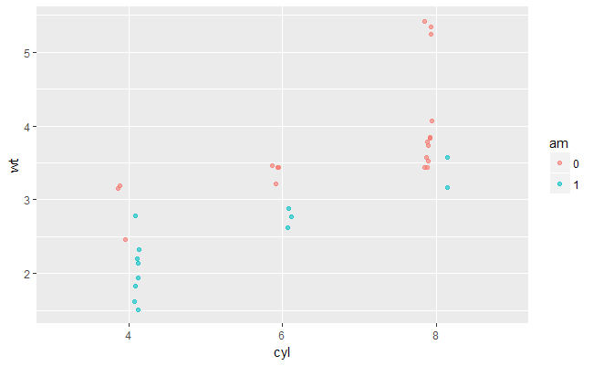

```r
# Plot1: Jiittered, doged scatter plot with transparent points
wt.cyl.am +
  geom_point(position = posn.jd, alpha = 0.6)
```

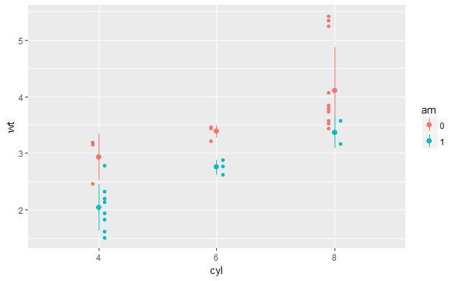

```r
# Plot2: Mean and SD - the easy way
wt.cyl.am +
  geom_point(position = posn.d) +
  stat_summary(fun.data = mean_sdl, fun.args = list(mult = 1))
```

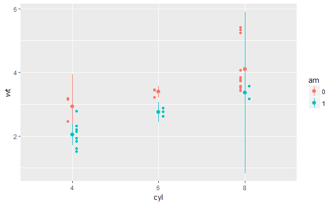

```r
# Plot3: Mean and 95% CI - the easy way
wt.cyl.am +
  geom_point(position = posn.d) +
  stat_summary(fun.data = mean_cl_normal)
```

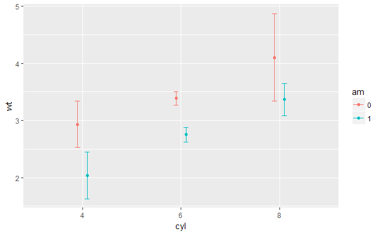

```r
# Plot4: Mean and SD = with T-tipped error bars
wt.cyl.am +
  stat_summary(geom = "point", fun.y = mean,
               position = posn.d) +
  stat_summary(geom = "errorbar", fun.data = mean_sdl,
               position = posn.d, fun.args = list(mult = 1), width = 0.1)
```

We can use our own functions to pass to the `fun.data()` call:

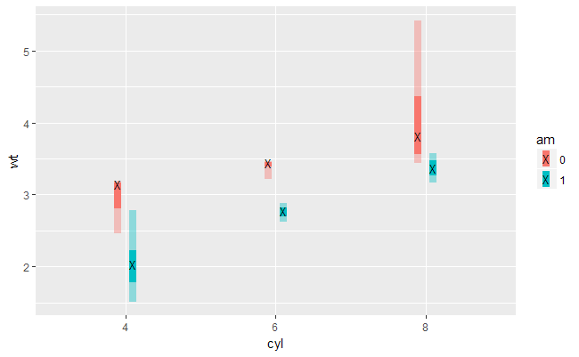

```r
gg_range <- function(x){
  data.frame(ymin = min(x),
             ymax = max(x))
}
med_IQR <- function(x){
  data.frame(y = median(x),
             ymin = quantile(x)[2],
             ymax = quantile(x)[4])
}
# Now we use these functions on the base plot
wt.cyl.am +
  stat_summary(geom = "linerange",
               fun.data = med_IQR, position = posn.d, size = 3) +
  stat_summary(geom = "linerange", fun.data = gg_range,
               position = posn.d, size = 3,
               alpha = 0.4) +
  stat_summary(geom = "point", fun.y = median,
               position = posn.d, size = 3,
               col = "black", shape = "X")
```